#### Dragos Ailoae

2021-09-19

# Introduction to R

### Bias, Consistency, Efficiency

To generate a fictitious population from the normal distribution:

```r
set.seed(12345)
pop <- rnorm(10000, 0, 1)             # normal distribution with mean of 0 and stdev of 1
```

To plot the histogram and kernel density:

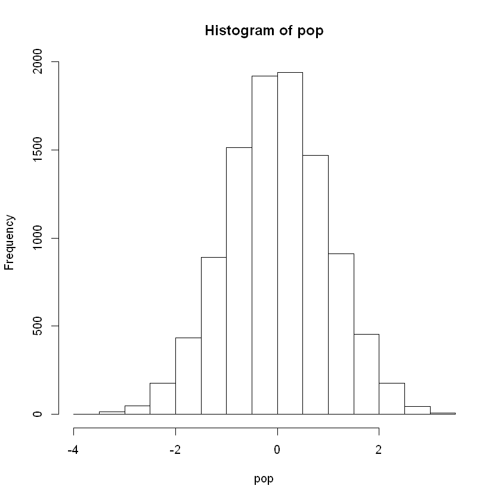

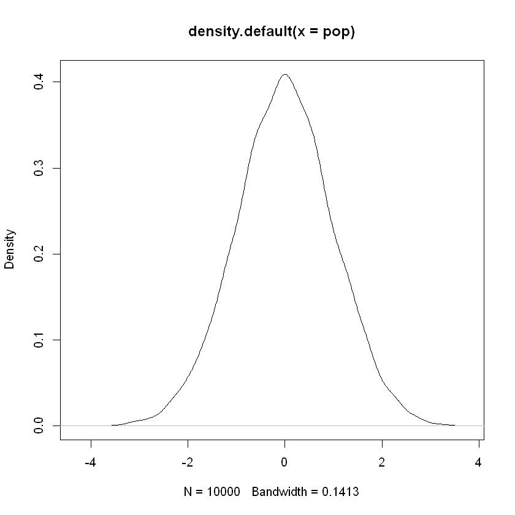

```r
hist(pop)
plot(density(pop))
```

The sample() function:

```r
one.sample<-sample(x = pop, size = 5)
one.sample
```

1. -0.577679954559021

2. 1.86348043744663

3. -0.107306609908684

4. -0.0741499437460166

5. -1.12194843349065

The replicate() function:

```r
set.seed(12345)
repetitions <- 30
many.samples <- replicate(repetitions,sample(x = pop, size = 5))
str(many.samples)
```

```
 num [1:5, 1:30] 0.0982 -0.0274 0.2376 -2.2806 -0.133 ...
```

To calculate the mean for each sample:

```r
means.of.many.samples <- colMeans(many.samples)
str(means.of.many.samples)
```

```
 num [1:30] -0.421 0.029 0.461 0.612 0.394 ...
```

Or we can combine all these steps into:

```r
set.seed(12345)
means.of.many.samples.alternate <- replicate(30, expr = mean(sample(x = pop, size = 5)))
str(means.of.many.samples.alternate)
```

```
 num [1:30] -0.421 0.029 0.461 0.612 0.394 ...
```

### Bias, Consistency and Efficiency

(based on *Introduction to Econometrics with R* by Hanck, Arnold, Gerber, and Schmelzer, 2020-09-15)

Desirable characteristics of an estimator include unbiasedness, consistency and efficiency.

**Unbiasedness:**

If the mean of the sampling distribution of some estimator $\hat\mu_{Y}$ for the population mean $\mu_{Y}$ equals $$E\left(\hat{\mu}_{Y}\right)=\mu_{Y}$$ then the estimator is unbiased for $\mu_{Y}$. The bias of $\hat\mu_{Y}$ then is : $$E\left(\hat{\mu}_{Y}\right)-\mu_{Y}=0$$

**Consistency:**

**Variance and efficiency:**

We want the estimator to be efficient. Suppose we have two estimators,$\hat{\mu}_{Y}$ and $\tilde{\mu}_{Y}$ and for some given sample size $n$ it holds that $$E\left(\hat{\mu}_{Y}\right)=E\left(\tilde{\mu}_{Y}\right)=\mu_{Y}$$

but $$\operatorname{Var}\left(\hat{\mu}_{Y}\right)<\operatorname{Var}\left(\tilde{\mu}_{Y}\right).$$

We then prefer to use $\hat{\mu}_{Y}$ as it has a lower variance than $\tilde{\mu}_{Y}$, meaning that $\hat{\mu}_{Y}$ is **more efficient** in using the information provided by the observations in the sample.

### Properties of the sample mean

To examine properties of the sample mean as an estimator for the corresponding population mean, consider the following R example.

We generate a population pop consisting of observations $Y_{i}, i=1, \ldots, 10000$ that origin from a normal distribution with mean $\mu=10$ and variance $\sigma^{2}=1.$

To investigate the behavior of the estimator $\hat{\mu}=\bar{Y}$ we can draw random samples from this population and calculate $\bar{Y}$ for each of them. This is easily done by making use of the function replicate (). The argument expr is evaluated $n$ times. In this case we draw samples of sizes $n=5$ and $n=25$, compute the sample means and repeat this exactly $N=25000$ times.

For comparison purposes we also store results for a third estimator $Y_{1}$, which estimates the population mean as the first observation in a sample of size 5 (the "first only" estimator).

```r
# generate a fictious population from the normal distribution
pop <- rnorm(10000, 10, 1)             # normal distribution with mean of 10 and stdev of 1
# sample from the population and estimate the mean
est1 <- replicate(expr = mean(sample(x = pop, size = 5)), n = 25000)

est2 <- replicate(expr = mean(sample(x = pop, size = 25)), n = 25000)

fo <- replicate(expr = sample(x = pop, size = 5)[1], n = 25000)     # "first only" estimator
```

The code chunk below produces a plot of the sampling distributions of the estimators $\bar{Y}$ and $Y_{1}$ on the basis of the 25000 samples in each case. We also plot the density function of the $\mathcal{N}(10,1)$ distribution.

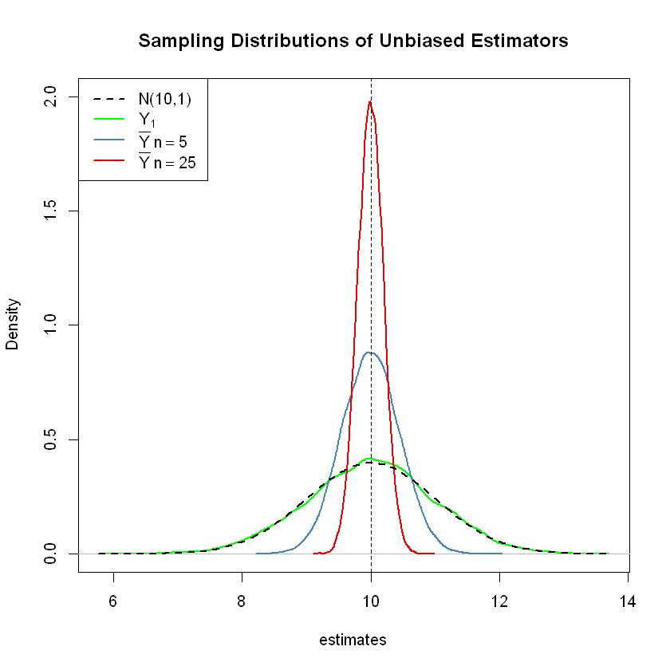

```r
# plot density estimate Y_1, the "first only" estimator
plot(density(fo),
      col = "green",
      lwd = 2,
      ylim = c(0, 2),
      xlab = "estimates",
      main = "Sampling Distributions of Unbiased Estimators")

# add density estimate for the distribution of the sample mean with n=5 to the plot
lines(density(est1),
     col = "steelblue",
     lwd = 2,
     bty = "l")

# add density estimate for the distribution of the sample mean with n=25 to the plot
lines(density(est2),
      col = "red2",
      lwd = 2)

# add a vertical line at the true parameter
abline(v = 10, lty = 2)

# add N(10,1) density to the plot
curve(dnorm(x, mean = 10),
     lwd = 2,
     lty = 2,
     add = T)

# add a legend
legend("topleft",
       legend = c("N(10,1)",
                  expression(Y[1]),
                  expression(bar(Y) ~ n == 5),
                  expression(bar(Y) ~ n == 25)
                  ),
       lty = c(2, 1, 1, 1),
       col = c("black","green", "steelblue", "red2"),
       lwd = 2)
```

First, all sampling distributions (represented by the solid lines) are centered around $\mu=10$. This is evidence for the **unbiasedness** of $Y_{1}, \bar{Y}_{5}$ and $\bar{Y}_{25} .$ Of course, the theoretical density $\mathcal{N}(10,1)$ is centered at 10, too. Next, have a look at the spread of the sampling distributions. Several things are noteworthy:

1. The sampling distribution of $Y_{1}$ (green curve) tracks the density of the $\mathcal{N}(10,1)$ distribution (black dashed line) pretty closely. In fact, the sampling distribution of $Y_{1}$ is the $\mathcal{N}(10,1)$ distribution. This is less surprising if you keep in mind that the $Y_{1}$ estimator does nothing but reporting an observation that is randomly selected from a population with $\mathcal{N}(10,1)$ distribution. Hence, $Y_{1} \sim \mathcal{N}(10,1) .$ Note that this result does not depend on the sample size $n:$ the sampling distribution of $Y_{1}$ is always the population distribution, no matter how large the sample is. $Y_{1}$ is a good a estimate of $\mu_{Y}$, but we can do better.
2. Both sampling distributions of $\bar{Y}$ show less dispersion than the sampling distribution of $Y_{1}$. This means that $\bar{Y}$ has a lower variance than $Y_{1} .$ We find that **$\bar{Y}$ is a more efficient estimator than $Y_{1}.$** In fact, this holds for all $n>1$
3. $\bar{Y}$ shows a behavior illustrating **consistency.** The blue and the red densities are much more concentrated around $\mu=10$ than the green one. As the number of observations is increased from 1 to 5 , the sampling distribution tightens around the true parameter. Increasing the sample size to 25 , this effect becomes more apparent. This implies that the probability of obtaining estimates that are close to the true value increases with $n$. This is also reflected by the estimated values of the density function close to $10:$ the larger the sample size, the larger the value of the density.